# Regression Analysis of the Number of Unemployed Persons

Mateusz Grabowski

### **1. Introduction**

#### **1.1 Purpose of the Analysis**

The aim of this project is to analyze the socio-economic factors influencing the number of unemployed persons in Poland and to develop a regression model enabling the forecasting of this variable in the future. Through the application of statistical methods and exploratory data analysis, it is possible to determine which factors have the greatest impact on the unemployment level and to evaluate the predictive effectiveness of the model.

#### **1.2 Scope of the Study**

The analysis covers data from the years 2010-2022, including, among others:

- Average salaries,
- Number of divorces,
- Number of crimes,
- Alcohol dependence,
- Number of foster families.

Based on this data, a linear regression model was created, allowing for the forecasting of the number of unemployed persons for the following year (2023). Additionally, a detailed diagnostic of the model was conducted to ensure it meets key statistical assumptions.

#### **1.3 Significance of the Study**

Unemployment is one of the key economic indicators, significantly impacting the country’s economic situation and the quality of life of its citizens. Understanding the factors determining the level of unemployment allows for better planning of employment policies and more effective counteraction of labor market problems.

The results of this analysis may be useful for economists, policymakers, and labor market analysts, enabling them to make better-informed decisions regarding social and economic policy.

### **2. Loading Packages**

```r
# Load necessary R packages, suppressing startup messages
suppressPackageStartupMessages({
  library(readxl)      # For reading Excel files
  library(ggplot2)     # For creating plots
  library(car)         # For regression diagnostics (e.g., VIF, Anova)
  library(lmtest)      # For diagnostic tests (e.g., Breusch-Pagan, Durbin-Watson)
  library(dplyr)       # For data manipulation
  library(purrr)       # For functional programming (used here for joining data)
  library(caret)       # For data pre-processing (e.g., nearZeroVar, findCorrelation)
  library(tseries)     # For time series analysis tests (e.g., Jarque-Bera)
  library(strucchange) # For testing structural changes in models (RESET test)
  library(forecast)    # For forecasting tools (though not heavily used here)
  library(writexl)     # For writing Excel files (if needed)
  library(scales)      # For scaling axes in plots (e.g., comma format)
  library(ggcorrplot)  # For visualizing correlation matrices
  library(tidyr)       # For tidying data (e.g., pivot_longer)
})
```

### **3. Loading and Processing Data**

In this section, data concerning various social and economic factors that may influence the unemployment level were loaded. All data originate from **Excel** files and contain information broken down by year.

*Note: Ensure the Excel files are in the correct working directory or provide full paths.*

#### **3.1 Loading Data**

The code below is responsible for importing data into the **R** environment using English variable names.

```r
# Function to read data from Excel files, select Year and Value columns, rename Value column
# Now includes prepending the 'data/' subdirectory to the filename
# Wrap in tryCatch for better error handling if files might be missing
load_excel_data <- function(filename_relative, value_col_name) {
  # Construct the full path relative to the project root
  full_path <- file.path("data", filename_relative)
  tryCatch({
    read_excel(full_path) %>%
      # Assuming Excel columns are named 'Rok' and 'Wartosc'
      select(Year = Rok, Value = Wartosc) %>%
      rename({{value_col_name}} := Value)
  }, error = function(e) {
    warning(paste("Could not load or process file:", full_path, "\nError:", e$message))
    # Return an empty tibble with expected columns
    tibble(Year = integer(), {{value_col_name}} := numeric())
  })
}

# Load data using NEW ENGLISH file names from the 'data' subfolder
vodka_price_data <- load_excel_data("vodka_price.xlsx", "vodka_price")
psychiatric_treatment_data <- load_excel_data("psychiatric_treatment.xlsx", "psychiatric_treatment")
crimes_data <- load_excel_data("crimes.xlsx", "crimes")
divorces_data <- load_excel_data("divorces.xlsx", "divorces")
alcohol_dependence_data <- load_excel_data("alcohol_dependence.xlsx", "alcohol_dependence")
salary_data <- load_excel_data("avg_salary.xlsx", "avg_salary")
aids_data <- load_excel_data("aids_cases.xlsx", "aids_cases")
unemployed_data <- load_excel_data("unemployed.xlsx", "unemployed")
housing_price_data <- load_excel_data("housing_price.xlsx", "housing_price")
prisoners_data <- load_excel_data("prisoners.xlsx", "prisoners")
foster_families_data <- load_excel_data("foster_families.xlsx", "foster_families")
liquidated_jobs_data <- load_excel_data("liquidated_jobs.xlsx", "liquidated_jobs")
employment_costs_data <- load_excel_data("employment_costs.xlsx", "employment_costs")

# Check if 'unemployed_data' loaded correctly, stop if not
if(nrow(unemployed_data) == 0) {
  stop("Failed to load the primary dependent variable file: data/unemployed.xlsx. Please check the file path and format.")
}
```

### **4. Data Conversion**

After loading the data, it was necessary to ensure format consistency, especially concerning the **Year** variable. In the source files, data might have been stored as text, so all year values were converted to a numeric format.

#### **4.1 Definition of the Conversion Function**

The following function **convert_year_to_numeric()** was used to change the values in the **Year** column to numbers.

```r
# Function to convert the 'Year' column to numeric, handles potential errors
convert_year_to_numeric <- function(df) {
  # Check if df is a valid data frame and has the 'Year' column
  if (!is.data.frame(df) || !"Year" %in% colnames(df)) {
      warning("Input is not a valid data frame or 'Year' column is missing.")
      return(df) # Return unchanged df or handle error differently
  }
  df %>%
      mutate(Year = suppressWarnings(as.numeric(as.character(Year)))) # Convert factor/char safely
}
```

#### **4.2 Applying the Conversion**

Converting the **Year** values to a numeric type allows for correct data merging, analysis, and statistical modeling. Otherwise, these values could be treated as categories or character strings, leading to errors in the analysis.

The function was applied to all loaded datasets, ensuring a uniform structure for the `Year` variable across all sets.

```r
# Apply conversion individually, checking if the df exists first.
if (exists("vodka_price_data") && is.data.frame(vodka_price_data)) vodka_price_data <- convert_year_to_numeric(vodka_price_data)
if (exists("psychiatric_treatment_data") && is.data.frame(psychiatric_treatment_data)) psychiatric_treatment_data <- convert_year_to_numeric(psychiatric_treatment_data)
if (exists("crimes_data") && is.data.frame(crimes_data)) crimes_data <- convert_year_to_numeric(crimes_data)
if (exists("divorces_data") && is.data.frame(divorces_data)) divorces_data <- convert_year_to_numeric(divorces_data)
if (exists("alcohol_dependence_data") && is.data.frame(alcohol_dependence_data)) alcohol_dependence_data <- convert_year_to_numeric(alcohol_dependence_data)
if (exists("salary_data") && is.data.frame(salary_data)) salary_data <- convert_year_to_numeric(salary_data)
if (exists("aids_data") && is.data.frame(aids_data)) aids_data <- convert_year_to_numeric(aids_data)
if (exists("unemployed_data") && is.data.frame(unemployed_data)) unemployed_data <- convert_year_to_numeric(unemployed_data)
if (exists("housing_price_data") && is.data.frame(housing_price_data)) housing_price_data <- convert_year_to_numeric(housing_price_data)
if (exists("prisoners_data") && is.data.frame(prisoners_data)) prisoners_data <- convert_year_to_numeric(prisoners_data)
if (exists("foster_families_data") && is.data.frame(foster_families_data)) foster_families_data <- convert_year_to_numeric(foster_families_data)
if (exists("liquidated_jobs_data") && is.data.frame(liquidated_jobs_data)) liquidated_jobs_data <- convert_year_to_numeric(liquidated_jobs_data)
if (exists("employment_costs_data") && is.data.frame(employment_costs_data)) employment_costs_data <- convert_year_to_numeric(employment_costs_data)
```

### **5. Merging Data**

After preparing the individual datasets, it was necessary to combine them into a single data frame **df_merged** based on the common variable **Year**.

#### **5.1 Merging Datasets**

To merge the data, the **reduce()** function from the **purrr** package and the **full_join()** method were used. This way, all datasets were combined into one table, retaining all available values for each year present in any file.

```r
# Create a list of data frames that were successfully loaded and converted
# Filter out any NULLs or non-dataframes resulting from load errors
valid_df_list <- Filter(function(x) is.data.frame(x) && nrow(x) > 0,
                        list(unemployed_data, vodka_price_data, psychiatric_treatment_data,
                             crimes_data, divorces_data, alcohol_dependence_data, salary_data,
                             aids_data, housing_price_data, prisoners_data, foster_families_data,
                             liquidated_jobs_data, employment_costs_data))

# Check if the list is not empty and contains 'unemployed_data'
if (length(valid_df_list) > 0 && any(sapply(valid_df_list, function(df) "unemployed" %in% colnames(df)))) {
  # Use reduce to sequentially join all valid data frames by 'Year'
  df_merged <- reduce(valid_df_list, full_join, by = "Year")

  # Display structure of the merged dataframe
  # print(str(df_merged))
  # print(head(df_merged))

} else {
  stop("No valid data frames available for merging, or 'unemployed_data' is missing.")
}
```

### **6. Data Cleaning and Preparation**

Before proceeding with regression modeling and data analysis, several cleaning and variable type conversion operations were necessary. This section describes the steps taken.

#### **6.1 Handling Missing or Non-Numeric Values**

Some data might contain non-numeric entries (like “-”) or be missing (NA) after the join. These need to be handled. We will replace “-” with NA and then remove rows with *any* NA value to ensure complete cases for the model.

```r
# Use df_merged from now on
# Replace any potential "-" strings with NA across the entire dataframe
df_merged <- as.data.frame(lapply(df_merged, function(col) {
  if (is.character(col) || is.factor(col)) {
     na_if(col, "-")
  } else {
    col
  }
}))

# Convert all columns (except Year, which should be numeric) to numeric, coercing errors to NA
df_merged <- df_merged %>%
    mutate(across(-Year, ~suppressWarnings(as.numeric(as.character(.)))))

# Remove rows with any NA values (listwise deletion)
df_complete <- na.omit(df_merged)

# Check dimensions before and after NA removal
# print(paste("Dimensions before NA removal:", paste(dim(df_merged), collapse="x")))
# print(paste("Dimensions after NA removal:", paste(dim(df_complete), collapse="x")))

# Stop if no complete cases remain
if(nrow(df_complete) == 0) {
  stop("No complete observations remain after removing NAs. Check input data quality.")
} else if (nrow(df_complete) < 10) { # Check if enough data points remain
   warning(paste("Only", nrow(df_complete), "complete observations remain. Model results may be unreliable."))
}
```

#### **6.2 Removing the ‘Year’ Column for Modeling**

The `Year` column serves only an indexing function and is not directly needed as a predictor in this specific regression model setup. It was removed from the dataset used for modeling.

```r
# Create df_model by removing the 'Year' column from the complete cases dataframe
if ("Year" %in% colnames(df_complete)) {
  df_model <- df_complete %>% select(-Year)
} else {
  df_model <- df_complete # Assume Year was already absent
}

# Ensure 'unemployed' column exists
if (!"unemployed" %in% colnames(df_model)) {
  stop("'unemployed' column not found in the prepared data frame 'df_model'.")
}

# Ensure all columns are numeric (redundant if done before na.omit, but safe)
df_model <- df_model %>% mutate(across(everything(), as.numeric))
```

### **7. Displaying Data Before Variable Removal**

Before starting the variable selection process, the first few rows of the prepared dataset (`df_model`) were displayed:

```r
# Display the head of the dataframe ready for modeling
print("Head of data frame before variable removal:")
```

```
## [1] "Head of data frame before variable removal:"
```

```r
head(df_model)
```

|  | unemployed | vodka_price | psychiatric_treatment | crimes | divorces | alcohol_dependence | avg_salary | aids_cases | housing_price | prisoners | foster_families | liquidated_jobs | employment_costs |
| --- | --- | --- | --- | --- | --- | --- | --- | --- | --- | --- | --- | --- | --- |
| 8 | 568687 | 19.59 | 198021 | 1138523 | 61300 | 1413357 | 3435.00 | 161 | 219318 | 80728 | 37395 | 456.5 | 552471 |
| 9 | 685237 | 19.90 | 201207 | 1159554 | 64594 | 1404148 | 3625.21 | 162 | 223534 | 81382 | 37344 | 429.3 | 586955 |
| 10 | 757239 | 20.27 | 197099 | 1119803 | 64432 | 1546155 | 3744.38 | 145 | 216626 | 84156 | 39537 | 376.5 | 611315 |
| 11 | 827080 | 20.37 | 195533 | 1061239 | 66132 | 1610543 | 3877.43 | 160 | 218758 | 78994 | 39144 | 347.1 | 623175 |
| 12 | 760056 | 21.67 | 201552 | 867855 | 65761 | 1595016 | 4003.99 | 149 | 224097 | 77371 | 38651 | 319.9 | 651507 |
| 13 | 620855 | 25.06 | 200760 | 799779 | 67296 | 1593125 | 4150.86 | 122 | 233963 | 70836 | 38203 | 317.6 | 678341 |

```r
# Display summary statistics
print("Summary of data frame before variable removal:")
```

```
## [1] "Summary of data frame before variable removal:"
```

```r
summary(df_model)
```

```
##    unemployed      vodka_price    psychiatric_treatment     crimes
##  Min.   :328664   Min.   :19.59   Min.   :163661        Min.   : 748459
##  1st Qu.:415520   1st Qu.:20.37   1st Qu.:189087        1st Qu.: 768049
##  Median :542843   Median :24.37   Median :195817        Median : 820846
##  Mean   :544946   Mean   :23.49   Mean   :191836        Mean   : 897113
##  3rd Qu.:685237   3rd Qu.:25.06   3rd Qu.:199666        3rd Qu.:1061239
##  Max.   :827080   Max.   :29.01   Max.   :201552        Max.   :1159554
##     divorces     alcohol_dependence   avg_salary     aids_cases
##  Min.   :51164   Min.   :1404148    Min.   :3435   Min.   : 52.0
##  1st Qu.:61300   1st Qu.:1593125    1st Qu.:3877   1st Qu.: 95.0
##  Median :64432   Median :1610543    Median :4291   Median :122.0
##  Mean   :62959   Mean   :1633320    Mean   :4608   Mean   :119.7
##  3rd Qu.:65341   3rd Qu.:1676217    3rd Qu.:5182   3rd Qu.:149.0
##  Max.   :67296   Max.   :1955271    Max.   :6706   Max.   :162.0
##  housing_price      prisoners     foster_families liquidated_jobs
##  Min.   :216626   Min.   :67894   Min.   :35439   Min.   :251.4
##  1st Qu.:223534   1st Qu.:71528   1st Qu.:36006   1st Qu.:284.2
##  Median :238891   Median :73822   Median :37344   Median :317.6
##  Mean   :260161   Mean   :75088   Mean   :37297   Mean   :328.2
##  3rd Qu.:275961   3rd Qu.:78994   3rd Qu.:38203   3rd Qu.:347.1
##  Max.   :387781   Max.   :84156   Max.   :39537   Max.   :456.5
##  employment_costs
##  Min.   : 552471
##  1st Qu.: 623175
##  Median : 721998
##  Mean   : 778246
##  3rd Qu.: 915753
##  Max.   :1171448
```

#### **7.1 Dataset Characteristics**

Based on the summary and head, the dataset `df_model` contains the dependent variable `unemployed` and potential predictors (like `vodka_price`, `crimes`, `divorces`, `avg_salary`, `foster_families`, etc.), now as numeric columns with complete cases. The exact list depends on which files loaded successfully and which columns survived the join and NA removal.

### **8. Data Optimization (Feature Selection)**

To improve the quality of the regression model and avoid problems related to multicollinearity and low-variance predictors, some variables were removed.

1. **Removal of near-zero variance variables**.
2. **Removal of highly correlated variables** (absolute correlation > 0.70).

```r
# Ensure there are enough columns to perform selection
if (ncol(df_model) <= 2) {
  warning("Not enough predictor columns to perform feature selection.")
} else {

  # 1. Remove Near-Zero Variance Predictors
  # Identify predictors (all columns except 'unemployed')
  predictors_initial <- setdiff(colnames(df_model), "unemployed")
  # Use caret's nearZeroVar function
  nzv_indices <- nearZeroVar(df_model[, predictors_initial], saveMetrics = FALSE)

  if (length(nzv_indices) > 0) {
    nzv_cols_to_remove <- predictors_initial[nzv_indices]
    print(paste("Removing Near-Zero Variance columns:", paste(nzv_cols_to_remove, collapse=", ")))
    df_model <- df_model[, !(colnames(df_model) %in% nzv_cols_to_remove)]
  } else {
    print("No Near-Zero Variance columns found to remove.")
  }

  # Update predictor list after NZV removal
  predictors_after_nzv <- setdiff(colnames(df_model), "unemployed")

  # 2. Remove Highly Correlated Predictors
  if (length(predictors_after_nzv) > 1) { # Need at least 2 predictors for correlation
    # Calculate the correlation matrix for remaining predictors
    cor_matrix <- cor(df_model[, predictors_after_nzv], use = "complete.obs")
    # Find variables with absolute correlation above 0.70
    highly_correlated_indices <- findCorrelation(cor_matrix, cutoff = 0.70, names = FALSE) # Get indices

    if (length(highly_correlated_indices) > 0) {
      highly_correlated_cols_to_remove <- predictors_after_nzv[highly_correlated_indices]
      print(paste("Removing Highly Correlated columns:", paste(highly_correlated_cols_to_remove, collapse=", ")))
      df_model <- df_model[, !(colnames(df_model) %in% highly_correlated_cols_to_remove)]
    } else {
      print("No highly correlated columns (cutoff=0.70) found to remove.")
    }
  } else {
    print("Not enough predictors remaining to check for high correlation.")
  }
}
```

```
## [1] "No Near-Zero Variance columns found to remove."
## [1] "Removing Highly Correlated columns: employment_costs, avg_salary, vodka_price, housing_price, prisoners, alcohol_dependence, psychiatric_treatment, aids_cases, liquidated_jobs"
```

```r
# Display dimensions after feature selection
print(paste("Dimensions after variable removal:", paste(dim(df_model), collapse="x")))
```

```
## [1] "Dimensions after variable removal: 13x4"
```

```r
# Ensure 'unemployed' is still present
if (!"unemployed" %in% colnames(df_model)) {
  stop("'unemployed' column was removed during feature selection. Check the process.")
}
# Ensure at least one predictor remains
if (ncol(df_model) < 2) {
  stop("No predictor variables remain after feature selection.")
}
```

This process aims to make the model more stable and interpretable.

#### **8.1 Displaying Data After Variable Removal**

After applying the above operations, the dataset contains only the dependent variable and the selected predictors.

```r
print("Head of data frame after variable removal:")
```

```
## [1] "Head of data frame after variable removal:"
```

```r
head(df_model)
```

|  | unemployed | crimes | divorces | foster_families |
| --- | --- | --- | --- | --- |
| 8 | 568687 | 1138523 | 61300 | 37395 |
| 9 | 685237 | 1159554 | 64594 | 37344 |
| 10 | 757239 | 1119803 | 64432 | 39537 |
| 11 | 827080 | 1061239 | 66132 | 39144 |
| 12 | 760056 | 867855 | 65761 | 38651 |
| 13 | 620855 | 799779 | 67296 | 38203 |

```r
print("Remaining columns:")
```

```
## [1] "Remaining columns:"
```

```r
colnames(df_model)
```

```
## [1] "unemployed"      "crimes"          "divorces"        "foster_families"
```

The final dataset contains variables intended for building the regression model.

### **9. Building the Linear Regression Model**

To investigate the impact of the selected variables on the number of unemployed persons, a linear regression model was constructed using the final dataset `df_model`.

```r
# Build a linear model: unemployed explained by all other remaining variables in df_model
# Using `.` automatically includes all other columns as predictors
final_model <- lm(unemployed ~ ., data = df_model)
```

The linear regression model allows us to quantify the relationships between the predictors and the number of unemployed, and to make predictions.

#### **9.1 Linear Regression Model Summary**

An analysis of the model was performed using the `summary()` function.

```r
summary(final_model)
```

```
##
## Call:
## lm(formula = unemployed ~ ., data = df_model)
##
## Residuals:
##    Min     1Q Median     3Q    Max
## -91083 -37028  -6313  44720  80881
##
## Coefficients:
##                   Estimate Std. Error t value Pr(>|t|)
## (Intercept)     -3.640e+06  5.300e+05  -6.867 7.33e-05 ***
## crimes           2.536e-01  1.284e-01   1.975 0.079745 .
## divorces        -3.984e+00  5.329e+00  -0.748 0.473808
## foster_families  1.128e+02  1.891e+01   5.967 0.000211 ***
## ---
## Signif. codes:  0 '***' 0.001 '**' 0.01 '*' 0.05 '.' 0.1 ' ' 1
##
## Residual standard error: 61260 on 9 degrees of freedom
## Multiple R-squared:  0.9058, Adjusted R-squared:  0.8743
## F-statistic: 28.83 on 3 and 9 DF,  p-value: 6.019e-05
```

**Interpretation:**

The summary provides: - **Coefficients**: Estimates of the intercept and the effect of each predictor on `unemployed`. `Pr(>|t|)` gives the p-value for testing if each coefficient is significantly different from zero. - **R-squared**: The proportion of variance in `unemployed` explained by the model. `Adjusted R-squared` penalizes for the number of predictors. - **F-statistic**: Tests the overall significance of the model.

#### **9.2 Test for Normality of Residuals (Shapiro-Wilk)**

Checking if the residuals follow a normal distribution.

```r
# Perform Shapiro-Wilk test on model residuals
shapiro_test_result <- shapiro.test(residuals(final_model))
print(shapiro_test_result)
```

```
##
##  Shapiro-Wilk normality test
##
## data:  residuals(final_model)
## W = 0.96597, p-value = 0.842
```

```r
# Interpretation help
if (shapiro_test_result$p.value > 0.05) {
  print("Shapiro-Wilk Test: p > 0.05, Do not reject H0. Residuals appear normally distributed.")
} else {
  print("Shapiro-Wilk Test: p <= 0.05, Reject H0. Residuals do not appear normally distributed.")
}
```

```
## [1] "Shapiro-Wilk Test: p > 0.05, Do not reject H0. Residuals appear normally distributed."
```

#### **9.3 Model Specification Test (RESET test)**

Checks for potential specification errors, like omitted non-linear terms.

```r
# Perform RESET test
reset_test_result <- resettest(final_model)
print(reset_test_result)
```

```
##
##  RESET test
##
## data:  final_model
## RESET = 2.7194, df1 = 2, df2 = 7, p-value = 0.1337
```

```r
# Interpretation help
if (reset_test_result$p.value > 0.05) {
  print("RESET Test: p > 0.05, Do not reject H0. No evidence of misspecification found.")
} else {
  print("RESET Test: p <= 0.05, Reject H0. Evidence of potential misspecification (e.g., missing non-linearity).")
}
```

```
## [1] "RESET Test: p > 0.05, Do not reject H0. No evidence of misspecification found."
```

#### **9.4 Multicollinearity Diagnostics (VIF - Variance Inflation Factor)**

VIF measures inflation in the variance of coefficient estimates due to collinearity.

```r
# Calculate VIF values
# Ensure there are at least 2 predictors
if (length(coef(final_model)) > 2) {
    vif_values <- vif(final_model)
    print("Variance Inflation Factor (VIF):")
    print(vif_values)

    # Interpretation help
    if (any(vif_values > 10)) {
      print("VIF Interpretation: At least one VIF > 10, indicating potentially problematic multicollinearity.")
    } else if (any(vif_values > 5)) {
      print("VIF Interpretation: At least one VIF > 5, indicating moderate multicollinearity. Investigate further.")
    } else {
      print("VIF Interpretation: All VIF values are low (< 5), suggesting multicollinearity is not a major issue.")
    }
} else {
    print("VIF calculation requires at least two predictor variables in the model.")
}
```

```
## [1] "Variance Inflation Factor (VIF):"
##          crimes        divorces foster_families
##        1.352327        1.571372        2.003599
## [1] "VIF Interpretation: All VIF values are low (< 5), suggesting multicollinearity is not a major issue."
```

#### **9.5 Breusch-Pagan Test – Heteroscedasticity**

Tests if the variance of the residuals is constant.

```r
# Perform Breusch-Pagan test
bp_test_result <- bptest(final_model)
print(bp_test_result)
```

```
##
##  studentized Breusch-Pagan test
##
## data:  final_model
## BP = 6.6378, df = 3, p-value = 0.08438
```

```r
# Interpretation help
if (bp_test_result$p.value > 0.05) {
  print("Breusch-Pagan Test: p > 0.05, Do not reject H0. No significant evidence of heteroscedasticity found.")
} else {
  print("Breusch-Pagan Test: p <= 0.05, Reject H0. Evidence of heteroscedasticity (non-constant variance).")
}
```

```
## [1] "Breusch-Pagan Test: p > 0.05, Do not reject H0. No significant evidence of heteroscedasticity found."
```

#### **9.6 Jarque-Bera Test – Normality of Residuals**

Another test for the normality of residuals.

```r
# Perform Jarque-Bera test
jb_test_result <- jarque.bera.test(residuals(final_model))
print(jb_test_result)
```

```
##
##  Jarque Bera Test
##
## data:  residuals(final_model)
## X-squared = 0.58545, df = 2, p-value = 0.7462
```

```r
# Interpretation help
if (jb_test_result$p.value > 0.05) {
  print("Jarque-Bera Test: p > 0.05, Do not reject H0. Residuals appear normally distributed.")
} else {
  print("Jarque-Bera Test: p <= 0.05, Reject H0. Residuals do not appear normally distributed.")
}
```

```
## [1] "Jarque-Bera Test: p > 0.05, Do not reject H0. Residuals appear normally distributed."
```

#### **9.7 Analysis of Variance (ANOVA)**

ANOVA table showing the sequential contribution of each predictor.

```r
# Display ANOVA table for the model using car::Anova for Type II SS is often preferred
# anova_result <- car::Anova(final_model, type="II")
# Or use base anova for sequential (Type I) SS
anova_result <- anova(final_model)
print(anova_result)
```

```
## Analysis of Variance Table
##
## Response: unemployed
##                 Df     Sum Sq    Mean Sq F value    Pr(>F)
## crimes           1 1.4896e+11 1.4896e+11  39.687 0.0001410 ***
## divorces         1 4.2059e+10 4.2059e+10  11.206 0.0085576 **
## foster_families  1 1.3363e+11 1.3363e+11  35.603 0.0002109 ***
## Residuals        9 3.3780e+10 3.7534e+09
## ---
## Signif. codes:  0 '***' 0.001 '**' 0.01 '*' 0.05 '.' 0.1 ' ' 1
```

#### **9.8 Durbin-Watson Test – Autocorrelation**

Tests for correlation between residuals from consecutive observations.

```r
# Perform Durbin-Watson test
dw_test_result <- dwtest(final_model)
print(dw_test_result)
```

```
##
##  Durbin-Watson test
##
## data:  final_model
## DW = 2.318, p-value = 0.5066
## alternative hypothesis: true autocorrelation is greater than 0
```

```r
# Interpretation help
if (dw_test_result$p.value > 0.05) {
  print("Durbin-Watson Test: p > 0.05, Do not reject H0. No significant evidence of autocorrelation found.")
} else {
  print("Durbin-Watson Test: p <= 0.05, Reject H0. Evidence of autocorrelation.")
}
```

```
## [1] "Durbin-Watson Test: p > 0.05, Do not reject H0. No significant evidence of autocorrelation found."
```

### **10. Diagnostic Analysis of the Regression Model**

Visual diagnostics help assess model assumptions.

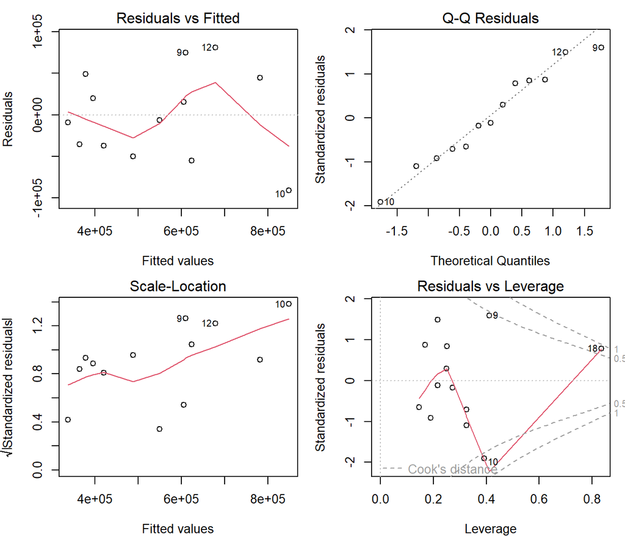

```r
# Set up plot layout (2x2 grid)
par(mfrow = c(2, 2), mar = c(4, 4, 2, 1))
# Generate standard diagnostic plots
plot(final_model)
```

```r
# Reset plot layout to default
par(mfrow = c(1, 1), mar = c(5, 4, 4, 2) + 0.1)
```

#### **10.1 Interpretation of Diagnostic Plots**

1. **Residuals vs Fitted**: Checks linearity and homoscedasticity.
2. **Normal Q-Q**: Checks normality of residuals.
3. **Scale-Location**: Checks homoscedasticity.
4. **Residuals vs Leverage**: Identifies influential points.

### **11. Actual vs. Predicted Unemployment Values**

Visualizing how well the model’s predictions match the actual data.

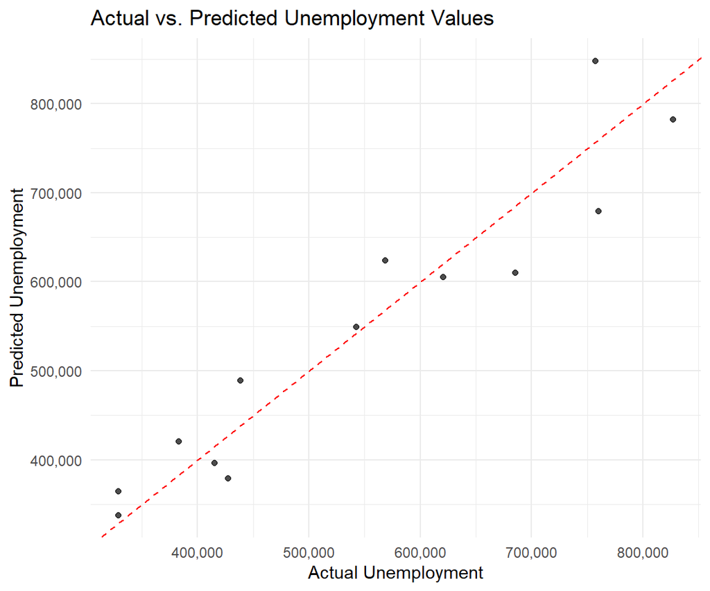

```r
# Create plot of actual vs predicted values
# Add predictions to the df_model dataframe for plotting
df_plot <- df_model
df_plot$predicted_unemployed <- predict(final_model)

ggplot(df_plot, aes(x = unemployed, y = predicted_unemployed)) +
  geom_point(alpha = 0.7) +
  geom_abline(slope = 1, intercept = 0, color = "red", linetype = "dashed") + # y=x line
  labs(title = "Actual vs. Predicted Unemployment Values",
       x = "Actual Unemployment",
       y = "Predicted Unemployment") +
  scale_x_continuous(labels = scales::comma) +
  scale_y_continuous(labels = scales::comma) +
  theme_minimal()
```

#### **Interpretation**

Points clustering closely around the red dashed line indicate good model fit.

### **12. Preparing Data for Forecasting (Year 2023)**

To forecast for 2023, we need estimated values for the predictors used in the final model (`final_model`) for that year. We use linear time trend extrapolation.

```r
# Ensure 'df_merged' (merged data before NA removal) exists
if (!exists("df_merged")) {
  stop("Required data frame 'df_merged' not found for forecasting prep.")
}

# Get the list of predictors used in the final model
final_predictors <- setdiff(names(coef(final_model)), "(Intercept)")

# Select these predictors and 'Year' from the original merged data 'df_merged'
df_for_trends <- df_merged %>%
  select(Year, all_of(final_predictors)) %>%
  # Ensure Year is numeric
  mutate(Year = as.numeric(Year)) %>%
  arrange(Year)

# Check the range of years available
available_years <- range(df_for_trends$Year, na.rm = TRUE)
print(paste("Years available for trend fitting:", available_years[1], "-", available_years[2]))
```

```
## [1] "Years available for trend fitting: 1999 - 2024"
```

```r
# Target year for forecast
forecast_year <- 2023
```

### **13. Forecasting Predictor Values for 2023**

Extrapolate each predictor to 2023 using a linear model based on ‘Year’.

```r
# Create a data frame for the year we want to predict
new_data_trends <- data.frame(Year = forecast_year)

# Data frame to store forecasted predictor values
forecasted_predictors_2023 <- data.frame(Year = forecast_year)

# Loop through each final predictor
for (var in final_predictors) {
  # Prepare data for this variable's trend model (remove NAs for this specific variable)
  trend_data_var <- df_for_trends %>%
                      select(Year, all_of(var)) %>%
                      filter(!is.na(.data[[var]])) # Use .data pronoun

  # Check if enough data points exist
  if (nrow(trend_data_var) >= 5) {
      # Build linear model: predictor ~ Year
      # Use backticks for variable names that might be non-standard
      model_var_trend <- lm(as.formula(paste0("`", var, "` ~ Year")), data = trend_data_var)
      # Predict the value for forecast_year
      predicted_value <- predict(model_var_trend, newdata = new_data_trends)
      forecasted_predictors_2023[[var]] <- predicted_value
  } else {
      warning(paste("Not enough data points (<5) to fit trend for variable:", var, ". Cannot forecast."))
      forecasted_predictors_2023[[var]] <- NA
  }
}

# Remove the 'Year' column
forecasted_predictors_2023 <- forecasted_predictors_2023 %>% select(-Year)

# Check if any predictors failed to forecast
if (any(is.na(forecasted_predictors_2023))) {
  warning("Forecasting failed for some predictors. Prediction for 'unemployed' might be NA.")
}

print("Forecasted predictor values for 2023:")
```

```
## [1] "Forecasted predictor values for 2023:"
```

```r
print(forecasted_predictors_2023)
```

```
##     crimes divorces foster_families
## 1 661867.5 58909.72        36254.39
```

### **14. Comparing Forecast with Actual Value for 2023**

Use the forecasted predictor values to predict unemployment for 2023 using the main model (`final_model`) and compare it to the known actual value.

```r
# Predict 'unemployed' for 2023 using the main regression model
# Check existence and validity of forecasted_predictors_2023
if (exists("forecasted_predictors_2023") && is.data.frame(forecasted_predictors_2023) && all(!is.na(forecasted_predictors_2023))) {
    forecast_unemployed_value <- predict(final_model, newdata = forecasted_predictors_2023)
    print(paste("Forecasted number of unemployed for 2023:", round(forecast_unemployed_value)))
} else {
    forecast_unemployed_value <- NA
    print("Cannot forecast 'unemployed' due to missing or invalid forecasted predictor values.")
}
```

```
## [1] "Forecasted number of unemployed for 2023: 383842"
```

```r
# Retrieve the actual value for 2023 from the original 'unemployed_data' dataframe
actual_unemployed_df_2023 <- NULL # Initialize
if (exists("unemployed_data") && is.data.frame(unemployed_data)) {
    actual_unemployed_df_2023 <- unemployed_data %>% filter(Year == forecast_year)
}

# Initialize actual value as NA
actual_unemployed_value <- NA

# Check if exactly one row was found
if (!is.null(actual_unemployed_df_2023) && nrow(actual_unemployed_df_2023) == 1) {
  # Attempt to retrieve and convert the value robustly
  retrieved_value <- actual_unemployed_df_2023$unemployed
  converted_value <- suppressWarnings(as.numeric(as.character(retrieved_value)))

  if (!is.na(converted_value)) {
      actual_unemployed_value <- converted_value
      print(paste("Actual number of unemployed in 2023:", round(actual_unemployed_value)))
  } else {
      print(paste("Actual value for 2023 found but is non-numeric:", retrieved_value))
  }

} else if (!is.null(actual_unemployed_df_2023) && nrow(actual_unemployed_df_2023) > 1) {
    print(paste("Warning: Multiple entries found for Year =", forecast_year, "in 'unemployed_data'. Cannot determine unique actual value."))
} else {
    print(paste("Actual value for Year =", forecast_year, "not found in the 'unemployed_data'."))
}
```

```
## [1] "Actual number of unemployed in 2023: 299738"
```

```r
# Calculate forecast error only if both values are available and numeric
if (!is.na(forecast_unemployed_value) && !is.na(actual_unemployed_value)) {
  forecast_error <- actual_unemployed_value - forecast_unemployed_value
  if (actual_unemployed_value != 0) {
      percent_error <- (forecast_error / actual_unemployed_value) * 100
      print(paste("Forecast Percent Error:", round(percent_error, 2), "%"))
  } else {
      percent_error <- NA
      print("Cannot calculate percent error because actual value is zero.")
  }
  print(paste("Forecast Error (Actual - Forecast):", round(forecast_error)))
} else {
    print("Cannot calculate forecast error because forecast or actual value is missing or non-numeric.")
}
```

```
## [1] "Forecast Percent Error: -28.06 %"
## [1] "Forecast Error (Actual - Forecast): -84104"
```

### **15. Visualization of the Unemployment Forecast for 2023**

Plot the historical unemployment trend along with the 2023 forecast and actual value.

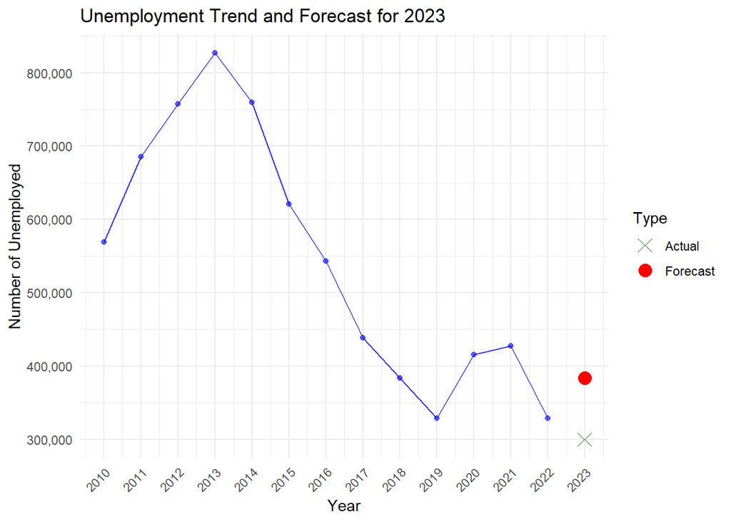

```r
# Prepare historical data (use df_complete which has complete cases used for modeling)
df_hist_plot <- df_complete %>% arrange(Year)

# Create data frame for the forecast point
if (!is.na(forecast_unemployed_value)) {
    forecast_point_df <- data.frame(Year = forecast_year, unemployed = forecast_unemployed_value, Type = "Forecast")
} else {
    forecast_point_df <- NULL
}

# Create data frame for the actual point
if (!is.na(actual_unemployed_value)) {
    actual_point_df <- data.frame(Year = forecast_year, unemployed = actual_unemployed_value, Type = "Actual")
} else {
    actual_point_df <- NULL
}

# Combine points for plotting
points_df <- bind_rows(forecast_point_df, actual_point_df)

# Plot
ggplot(df_hist_plot, aes(x = Year, y = unemployed)) +
  geom_line(color = "blue", alpha=0.8) +
  geom_point(color = "blue", alpha=0.6) +
  geom_point(data = points_df, aes(x = Year, y = unemployed, color = Type, shape = Type), size = 4) +
  scale_color_manual(values = c("Forecast" = "red", "Actual" = "darkgreen")) +
  scale_shape_manual(values = c("Forecast" = 16, "Actual" = 4)) + # Circle for forecast, X for actual
  labs(title = paste("Unemployment Trend and Forecast for", forecast_year),
       x = "Year", y = "Number of Unemployed") +
  scale_y_continuous(labels = scales::comma) +
  scale_x_continuous(breaks = seq(min(df_hist_plot$Year), forecast_year, by = 1)) +
  theme_minimal() +
  theme(axis.text.x = element_text(angle = 45, hjust = 1))
```

### **16. Correlation Matrix Between Final Variables**

Visualize the correlations among the variables included in the final model (`df_model`).

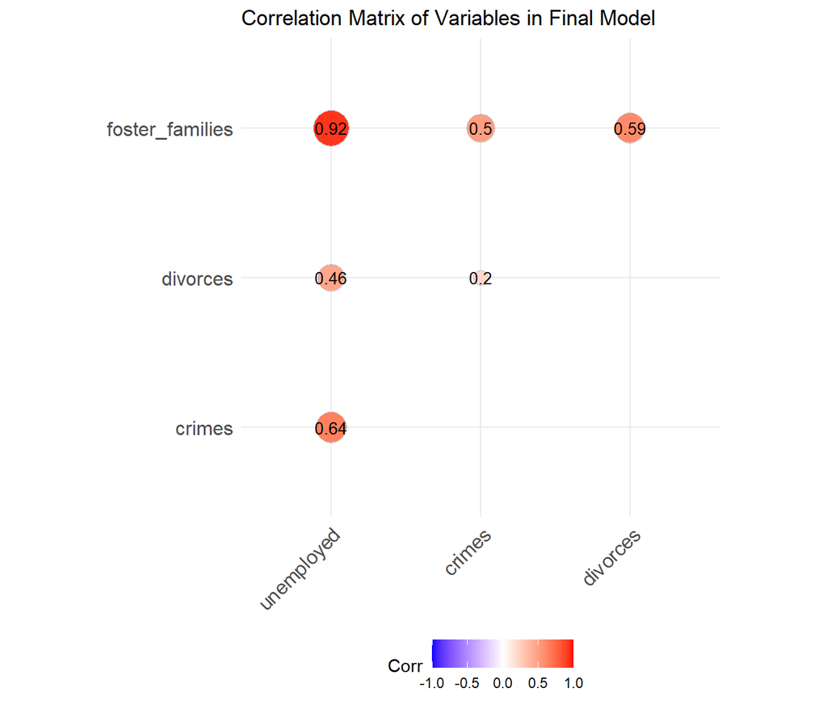

```r
# Calculate the correlation matrix for the final dataset used in the model
cor_matrix_final <- cor(df_model, use = "complete.obs")

# Visualize the correlation matrix
ggcorrplot(cor_matrix_final,
           method = "circle",
           type = "upper",
           ggtheme = ggplot2::theme_minimal,
           lab = TRUE,
           lab_size = 3.5,
           title = "Correlation Matrix of Variables in Final Model") +
  theme(legend.position = "bottom")
```

### **17. Time Trends of Final Variables**

Plot the time trends of the variables included in the final model (`df_model`).

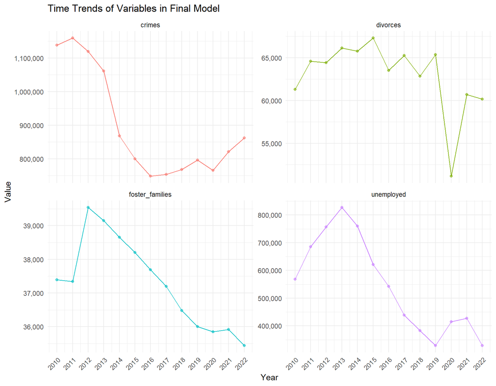

```r
# Add 'Year' back to df_model for plotting trends
df_model_trends <- df_model
# Check if rownames exist and match before using them
if (all(rownames(df_model) %in% rownames(df_complete))) {
    df_model_trends$Year <- df_complete[rownames(df_model), "Year"]
} else {
    warning("Row names do not match between df_model and df_complete. Cannot reliably add 'Year' for trend plot.")
    df_model_trends$Year <- NA # Add Year as NA if cannot match
}

# Reshape data from wide to long format only if Year was added successfully
if (!any(is.na(df_model_trends$Year))) {
    df_long_final <- df_model_trends %>%
                        pivot_longer(cols = -Year, names_to = "Variable", values_to = "Value")

    # Plot time trends using facets
    ggplot(df_long_final, aes(x = Year, y = Value, color = Variable)) +
      geom_line() +
      geom_point(alpha=0.6) +
      labs(title = "Time Trends of Variables in Final Model", x = "Year", y = "Value") +
      scale_x_continuous(breaks = seq(min(df_model_trends$Year), max(df_model_trends$Year), by = 1)) +
      scale_y_continuous(labels = scales::comma) +
      theme_minimal() +
      facet_wrap(~ Variable, scales = "free_y") +
      theme(legend.position = "none",
            axis.text.x = element_text(angle = 45, hjust = 1))
} else {
    print("Skipping time trend plot as 'Year' could not be added back to df_model reliably.")
}
```

### **18. Histogram of the Number of Unemployed**

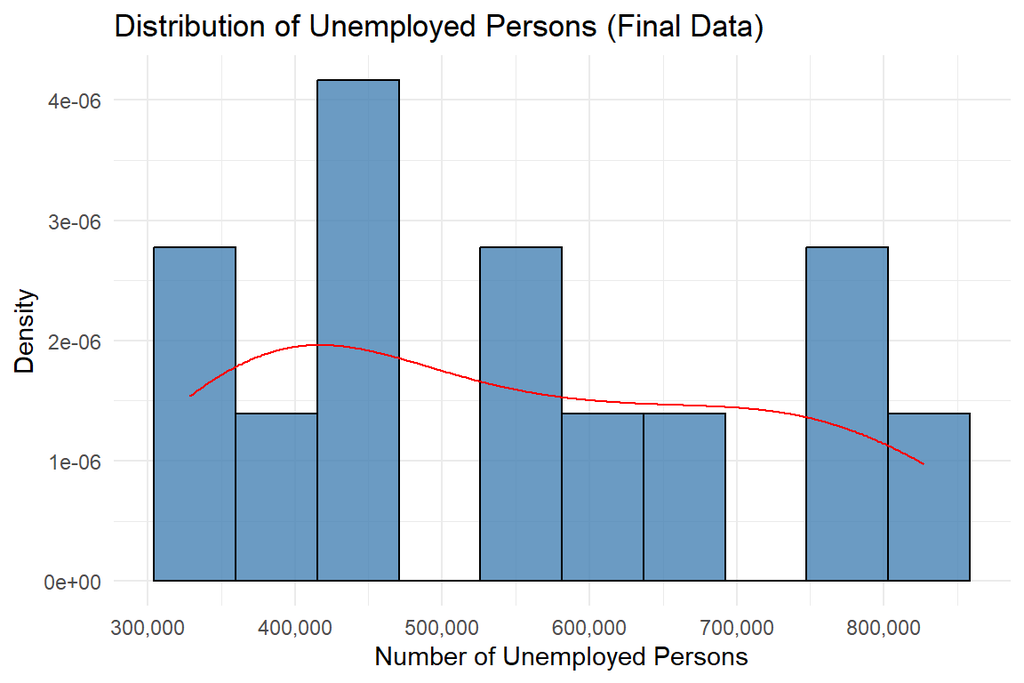

```r
# Create a histogram for the 'unemployed' variable from the final modeling dataset df_model
ggplot(df_model, aes(x = unemployed)) +
  geom_histogram(aes(y = after_stat(density)), fill = "steelblue", bins = 10, alpha = 0.8, color="black") +
  geom_density(color = "red") +
  labs(title = "Distribution of Unemployed Persons (Final Data)",
       x = "Number of Unemployed Persons",
       y = "Density") +
  scale_x_continuous(labels = scales::comma) +
  theme_minimal()
```

### **19. Box Plot for Final Variables**

Show the distribution of each variable in the final model using box plots.

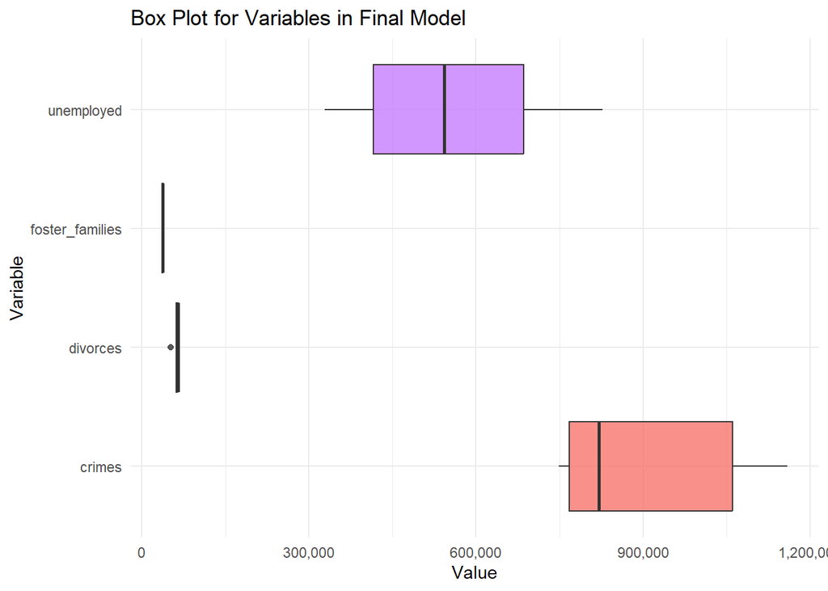

```r
# Reuse the long format data from the time trend plot section for final variables
if (exists("df_long_final") && is.data.frame(df_long_final)) {
    # Create box plots, excluding Year if it exists
    ggplot(df_long_final %>% filter(Variable != "Year"), aes(x = Variable, y = Value, fill = Variable)) +
      geom_boxplot(alpha=0.8) +
      coord_flip() +
      labs(title = "Box Plot for Variables in Final Model", x = "Variable", y = "Value") +
      scale_y_continuous(labels = scales::comma) +
      theme_minimal() +
      theme(legend.position = "none")
} else {
    print("Skipping box plot as data ('df_long_final') is not available.")
}
```

### **20. Summary of the Regression Analysis**

#### **20.1 Purpose and Approach**

The project analyzed socio-economic factors potentially influencing unemployment in Poland (2010-2022 data). A linear regression model was built to explain and predict the number of unemployed persons after data cleaning, merging, and feature selection.